# Basic GLMs in R

Clarke van Steenderen

2025-02

# **R tutorial 5: Running Generalised Linear Models (GLMs)**

A GLM is a more versatile version of a linear regression model. It accepts a wider variety of response variable types, such as count and binary data. This is often useful when a data set does not meet the expected statistical assumptions required in the linear modelling process (i.e. Gaussian expectations). When applying linear models, one assumes that the error terms have a normal distribution (i.e. there is a constant relationship between mean and variance). GLMs, however, can be applied when error structures are non-normal.

Data types are numerous, where you will typically have one or more of the following:

- Continuous -> e.g. measurements of height, mass, length, temperature
- Count -> e.g. number of species
- Proportion -> e.g. the proportion of a population that shares a morphological feature
- Binary -> e.g. dead or alive, male or female, healthy or sick
- Categorical/factors -> e.g. different groups, such as a control and drug treatments

Here is a general guide to choosing which statistical test may be best suited for your data. Have a look at [Dai Shizuka’s site](https://dshizuka.github.io/RCourse/05.1.Stats_LinearModels.html) for additional examples. If you have:

- A continuous predictor AND continuous response variable -> use linear regression or a GLM with **Gaussian** distribution
- A continuous predictor AND binary response variable -> GLM with the **“binomial”** family (logistic regression)
- A continuous predictor AND counts as response variable -> GLM with **“Poisson”** or **“Negative binomial”** family (Poisson regression)
- A continuous predictor AND proportions as response variable -> GLM with **“binomial”** family
- A categorical predictor AND continuous response variable -> **ANOVA** (or t-test, if you are just comparing means), which can be also be run as a linear model or GLM. An ANOVA is essentially a LM or a GLM, just with a categorical predictor variable. An ANOVA compares means across groups, and looks at the variance between and within groups. If variance is greater between than within those groups, there is a significant difference between them.
- A categorical predictor AND counts as response variable -> GLM with **“Poisson”** or **“Negative binomial”** family (Poisson regression)
- Multiple predictors, with some continuous and some categorical variables -> linear regression / GLM
- If you have a continuous response variable (irrespective of predictor type) that is only ever positive and right-skewed, a Gamma distribution is appropriate (e.g `family = Gamma(link = "log")`). Such values could be survival times, time to failure, reaction times, concentrations, body size, biomass, etc. Plot the distribution of the raw data to check for skewness. A positive skew has a long positive tail.
- If you have a proportion/percentage/rate as a response variable (e.g. proportion of eggs that hatched, percentage vegetation cover, birth rate, metabolic or infection rate), a Beta distribution is appropriate. This takes in proportion values strictly between 0 and 1. The GLM function does not run a “beta” family, and so you need to use the `betareg() function in the betareg library`. If you wanted to convert your proportions to counts of success vs failure or presence vs absence, assuming only two states, you could use a binomial GLM. If there are more than two categories, you could use something like a multinomial regression model (`nnet::multinom()`).

**NOTE: offsets** Sometimes we may have an additional factor in our data that isn’t an actual parameter, but may need to be used to scale the data. For example, we might have measured the occurrence of a disease across different populations, but the population sizes and ages vary. Intuitively, larger populations will have a higher incidence of the disease and would appear to be more sickly than smaller populations; just because there is more data. Similarly, there may be differences in the age structures across the populations, where older people are more likely to become ill than younger people. In order to correct for population size and age, we can add the `offset` parameter to our GLMs, where we provide these correction variables. Another example might be a dataset containing species counts across different habitat types. One habitat might have five pitfall traps, while another had ten (or perhaps different amounts of time were spent at different sites). The sampling effort is therefore not consistent across all measures. This would then need to be accounted for as an offset in the model. An example of how this might be run in R with a Poisson GLM could be:

`glm(abundance ~ habitat + offset(log(observation_time) + log(trap_number)), family = poisson, data = my_data)`

**NOTE: sum-of-squares tests** A sum-of-squares test is applied when testing for the significance of your parameters. Generally, you would use a:

- Type I test when there is one predictor variable
- Type II test when there are two or more predictor variables AND NO interaction terms
- Type III test when there are two or more predictor variables AND an interaction term

The default **anova()** function in R runs a type I test, while the **car::Anova()** function can run type II and type III tests. If the interaction term in a type III test is not significant, re-run the test using type II to check the significance of the two predictor variables.

Let’s set up our R session:

```r
if (!require("pacman"))
  install.packages("pacman")
```

```r
pacman::p_load(xlsx, janitor, ggplot2, Rmisc, dplyr,
               tidyverse, visreg, glmmTMB, gtsummary, effects, ggeffects,
               patchwork, e1071)

# Set plot theme
theme_set(theme_classic() +
theme(panel.border = element_rect(colour = "black", fill = NA),
axis.text = element_text(colour = "black"),
axis.title.x = element_text(margin = unit(c(2, 0, 0, 0), "mm")),
axis.title.y = element_text(margin = unit(c(0, 4, 0, 0), "mm")),
legend.position = "none"))
```

# **A basic GLM -> growth rates across groups**

## **GAUSSIAN**

Running this Gaussian GLM is essentially the same as a standard ANOVA or linear model. Here is a data set with growth rates (continuous variable) of different *Daphnia* species in the presence of different parasites (i.e. categories). This data comes from the book *Getting Started with R: An Introduction for Biologists* by Andrew Beckerman et al. 2017. We’ll fit a Gaussian GLM here. Run a standard linear model and ANOVA for yourself as well, and compare the output.

```r
daphnia.data = read.csv("data/datasets_getting_started/Daphniagrowth.csv")
str(daphnia.data)
```

```
## 'data.frame':    40 obs. of  3 variables:
##  $ parasite   : chr  "control" "control" "control" "control" ...
##  $ rep        : int  1 2 3 4 5 6 7 8 9 10 ...
##  $ growth.rate: num  1.07 1.27 1.32 1.08 1.2 ...
```

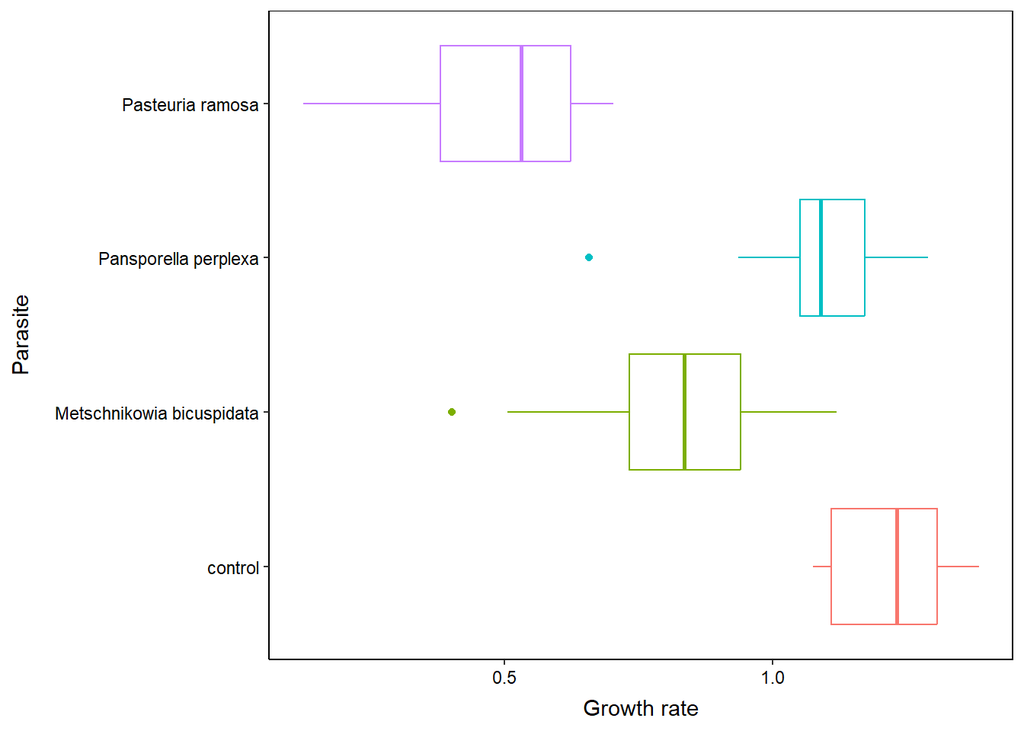

```r
# Plot growth rate against parasite
ggplot2::ggplot(data = daphnia.data,
                aes(x = parasite, y = growth.rate, colour = parasite)) +
  geom_boxplot() +
  coord_flip() +
  xlab("Parasite") +
  ylab("Growth rate")
```

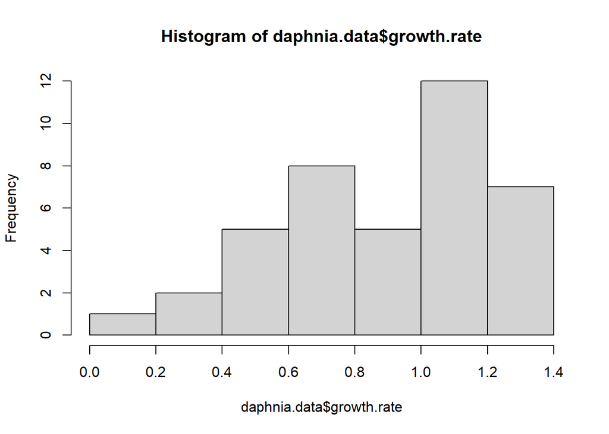

```r
hist(daphnia.data$growth.rate)
```

```r
# indicates a slight negative skew
e1071::skewness(daphnia.data$growth.rate)
```

```
## [1] -0.4923971
```

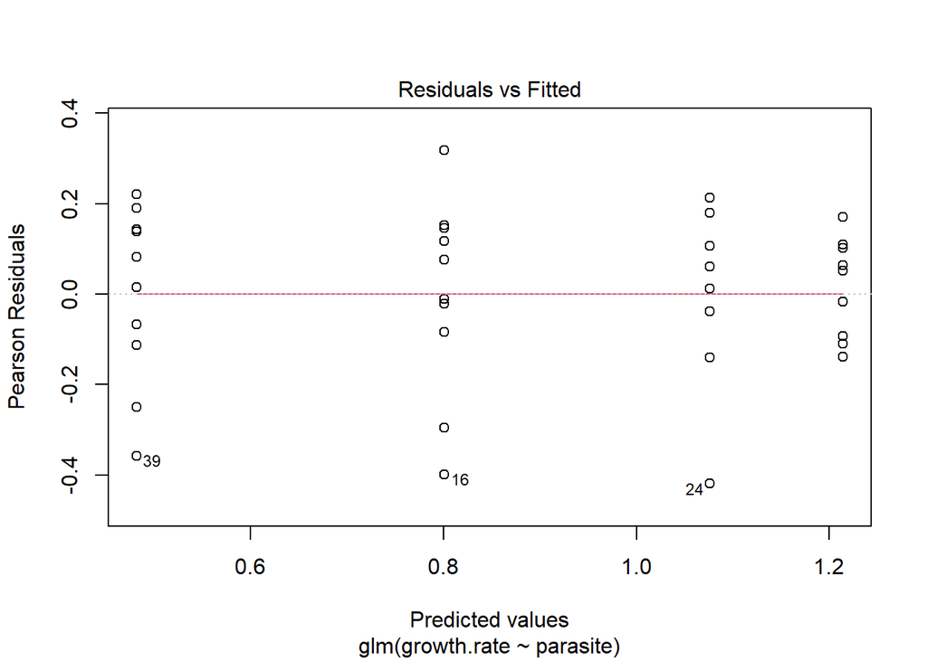

```r
# let's run a Gaussian GLM -> you could equally as easily run a linear model
daphnia.glm.gaus = glm(data = daphnia.data,
                              growth.rate ~ parasite,
                              family = gaussian)

# have a look at model diagnostics
plot(daphnia.glm.gaus, which = 1)
```

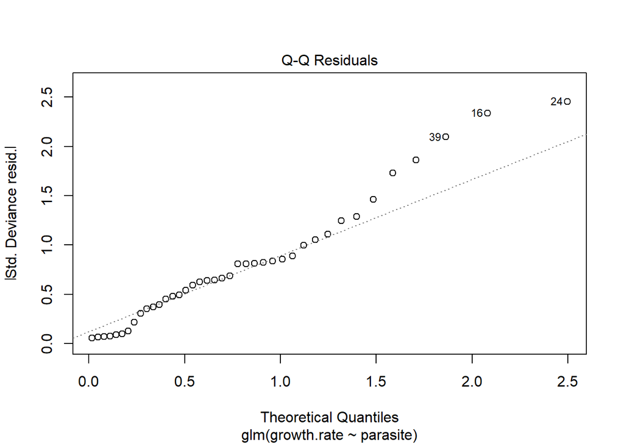

```r
plot(daphnia.glm.gaus, which = 2)
```

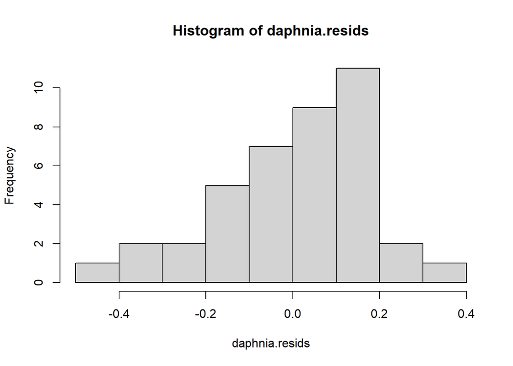

```r
daphnia.resids = resid(daphnia.glm.gaus)
hist(daphnia.resids)
```

```r
e1071::skewness(daphnia.resids)
```

```
## [1] -0.7164429
```

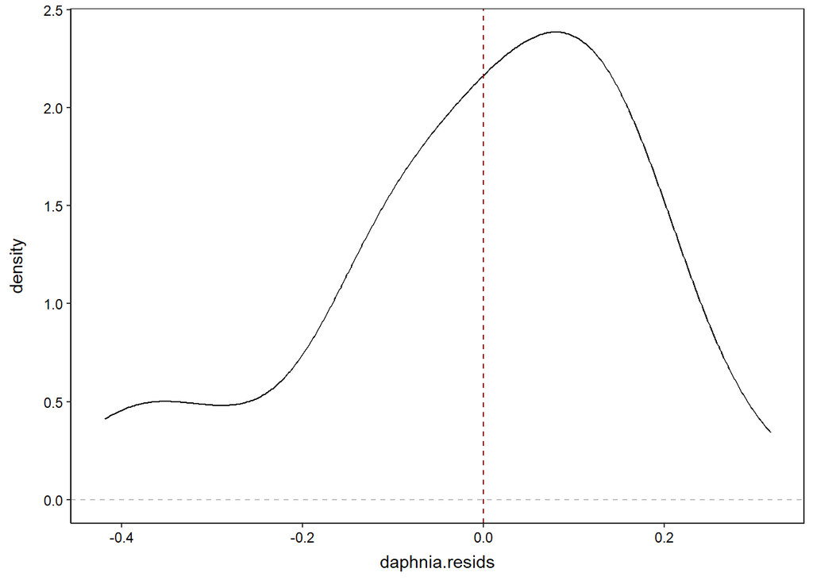

```r
daphnia.resids.df = as.data.frame(daphnia.resids)

daphnia.resids.mean = mean(daphnia.resids.df$daphnia.resids)

ggplot2::ggplot(data = daphnia.resids.df, aes(y = daphnia.resids)) +
  #geom_histogram() +
  geom_density() +
  coord_flip() +
  geom_hline(yintercept = 0, linetype = "dashed", color = "gray") +
  geom_vline(xintercept = 0, linetype = "dashed", color = "gray") +
  geom_hline(yintercept = daphnia.resids.mean, linetype = "dashed", color = "darkred")
```

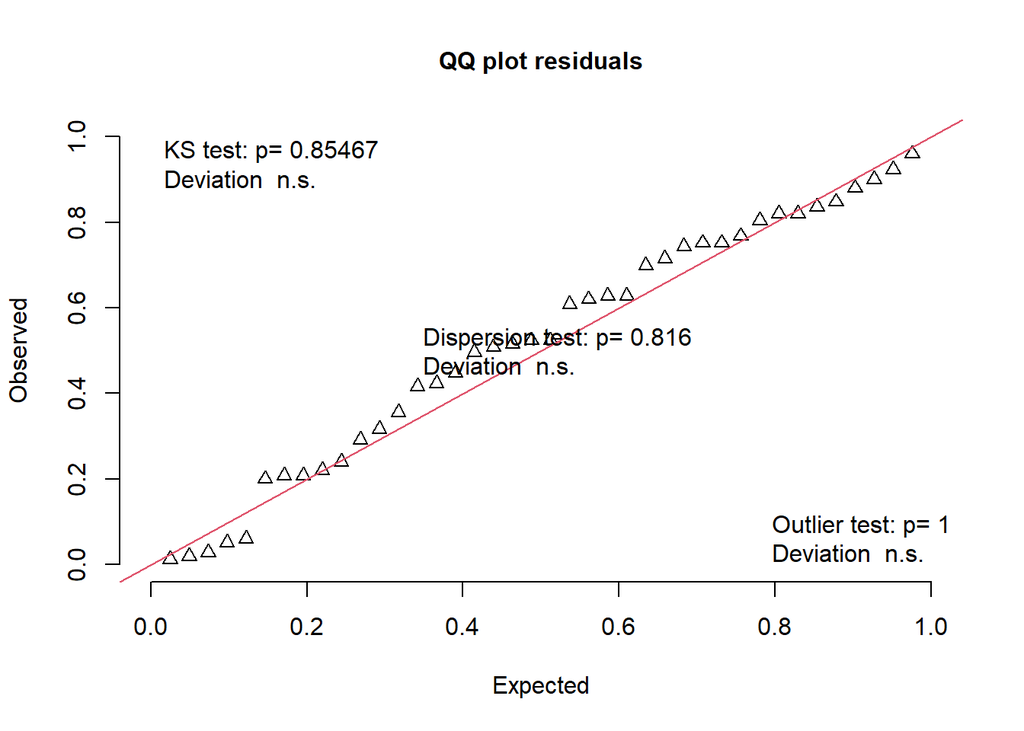

```r
DHARMa::plotQQunif(daphnia.glm.gaus)
```

```r
#performance::check_model(daphnia.glm.gaus, check = "normality")

# we'll run a likelihood ratio test
# here we see that parasite does have an effect on growth rate
# Note that we are not running an ANOVA here, but rather producing a
# deviance table

# use anova for type I
anova(daphnia.glm.gaus, test = "LR")
```

```
## Analysis of Deviance Table
##
## Model: gaussian, link: identity
##
## Response: growth.rate
##
## Terms added sequentially (first to last)
##
##
##          Df Deviance Resid. Df Resid. Dev  Pr(>Chi)
## NULL                        39     4.3028
## parasite  3   3.1379        36     1.1649 < 2.2e-16 ***
## ---
## Signif. codes:  0 '***' 0.001 '**' 0.01 '*' 0.05 '.' 0.1 ' ' 1
```

```r
# get means
daphnia.means = Rmisc::summarySE(daphnia.data, measurevar = "growth.rate",
                                 groupvars = "parasite")

# summary of the model
# notice how the control group is not in the results table. This is because
# it is represented by the Intercept, and the other parasites are compared
# to that. The Intercept will be taken as the first level (i.e. alphabetically)
# of your groups.
summary(daphnia.glm.gaus)
```

```
##
## Call:
## glm(formula = growth.rate ~ parasite, family = gaussian, data = daphnia.data)
##
## Coefficients:
##                                   Estimate Std. Error t value Pr(>|t|)
## (Intercept)                        1.21391    0.05688  21.340  < 2e-16 ***
## parasiteMetschnikowia bicuspidata -0.41275    0.08045  -5.131 1.01e-05 ***
## parasitePansporella perplexa      -0.13755    0.08045  -1.710   0.0959 .
## parasitePasteuria ramosa          -0.73171    0.08045  -9.096 7.34e-11 ***
## ---
## Signif. codes:  0 '***' 0.001 '**' 0.01 '*' 0.05 '.' 0.1 ' ' 1
##
## (Dispersion parameter for gaussian family taken to be 0.03235768)
##
##     Null deviance: 4.3028  on 39  degrees of freedom
## Residual deviance: 1.1649  on 36  degrees of freedom
## AIC: -17.935
##
## Number of Fisher Scoring iterations: 2
```

```r
# another neater way of viewing the summary results
gtsummary::tbl_regression(daphnia.glm.gaus)
```

| **Characteristic** | **Beta** | **95% CI**<sup>1</sup> | **p-value** |
| --- | --- | --- | --- |
| parasite |  |  |  |
| control | — | — |  |
| Metschnikowia bicuspidata | -0.41 | -0.57, -0.26 | <0.001 |
| Pansporella perplexa | -0.14 | -0.30, 0.02 | 0.10 |
| Pasteuria ramosa | -0.73 | -0.89, -0.57 | <0.001 |

<sup>1</sup> CI = Confidence Interval

```r
# notice the four levels of parasites in the data: R orders them alphabetically
# this is why the control (first in alphabetical order) is the reference
# in the summary output
levels(factor(daphnia.data$parasite))
```

```
## [1] "control"                   "Metschnikowia bicuspidata"
## [3] "Pansporella perplexa"      "Pasteuria ramosa"
```

If you wanted to change the order of the levels so that a different category becomes the baseline (other than “Control” in this dataset), you could use the `factor()` function and manually define the order of each. Perhaps you want *Pasteuria ramosa* to be first:

```
daphnia.data$parasite = factor(daphnia.data$parasite,
   levels = c("Pasteuria ramosa", "control", "Metschnikowia bicuspidata", "Pansporella perplexa"))
```

Let’s plot the mean growth rate for each treatment. The dotted line is at **x = 1.21391**, which is the mean of the control. See the Estimate values in the **summary(daphnia.glm.gaus)** output. When there is a single categorical predictor, the Intercept value is the mean of the reference variable (here, Control), and the Estimate values are the distances of the other variables from the reference mean. This changes when there are multiple predictors, or if the predictor is a continuous variable, so be careful. If we had an additional predictor, such as temperature, the Intercept value would be the growth rate of the control group when temperature = 0. If you wanted to change the reference temperature value to something other than zero, perhaps 1, you could add an additional column to the dataset, where you have temperature - 1. You would then use this centered temperature column as a predictor. This might take the form: `glm(growth.rate ~ parasite + temperature_centered, family = gaussian, data = daphnia.data)`.

Back to our model: the other negative values just indicate how far away each of the other parasites are away from the mean of the control treatment. For example, *M. bicuspidata* is -0.41275 away from the control -> 1.21391 - 0.41275 = 0.80116, and this difference is significant (p < 0.01). The horizontal black lines in the plot below show these distance differences from the control’s mean value (dotted vertical line).

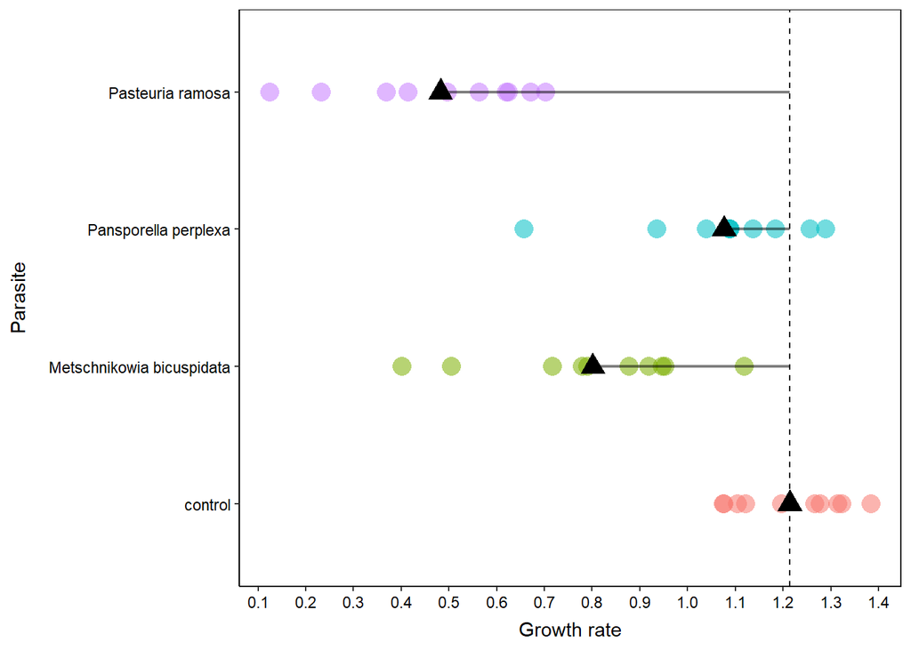

```r
ggplot2::ggplot() +
  geom_point(data = daphnia.data, shape = 16,
             aes(x = parasite, y = growth.rate,
                 colour = parasite, size = 8, alpha = 0.5)) +
  geom_point(data = daphnia.means, aes(x = parasite, y = growth.rate, size = 8),
             shape = 17) +
  geom_hline(yintercept = 1.21391, linetype = "dashed") +
  geom_segment(aes(y=1.21391, x=4, yend=0.4822030, xend=4),
               linewidth = 0.8, alpha = 0.5) +
  geom_segment(aes(y=1.21391, x=3, yend=1.0763551, xend=3),
               linewidth = 0.8, alpha = 0.5) +
  geom_segment(aes(y=1.21391, x=2, yend=0.8011541, xend=2),
               linewidth = 0.8, alpha = 0.5) +
  scale_y_continuous(breaks=seq(0,2,by=0.1)) +
  coord_flip() +
  xlab("Parasite") +
  ylab("Growth rate")
```

```r
# run some post hoc tests to see differences between groups
posthoc.daphnia = emmeans::emmeans(daphnia.glm.gaus, pairwise ~ parasite, adjust = "tukey")

posthoc.daphnia$contrasts %>%
  summary(infer = TRUE)
```

```
##  contrast                                         estimate     SE df lower.CL
##  control - Metschnikowia bicuspidata                 0.413 0.0804 36   0.1961
##  control - Pansporella perplexa                      0.138 0.0804 36  -0.0791
##  control - Pasteuria ramosa                          0.732 0.0804 36   0.5150
##  Metschnikowia bicuspidata - Pansporella perplexa   -0.275 0.0804 36  -0.4919
##  Metschnikowia bicuspidata - Pasteuria ramosa        0.319 0.0804 36   0.1023
##  Pansporella perplexa - Pasteuria ramosa             0.594 0.0804 36   0.3775
##  upper.CL t.ratio p.value
##    0.6294   5.131  0.0001
##    0.3542   1.710  0.3335
##    0.9484   9.096  <.0001
##   -0.0585  -3.421  0.0082
##    0.5356   3.965  0.0018
##    0.8108   7.386  <.0001
##
## Confidence level used: 0.95
## Conf-level adjustment: tukey method for comparing a family of 4 estimates
## P value adjustment: tukey method for comparing a family of 4 estimates
```

What can you conclude from these pairwise contrasts? Have a look at the plot again to check the comparison between *P. perplexa* and the control. Look at the signs of the estimate values. For example, the contrast between the control and *M. bicuspidata* is +0.413, with a p-value < 0.001. This means that the control was significantly higher than the *M. bicuspidata* parasite. The *M. bicuspidata* - *P. perplexa* comparison was -0.275, which means that *M. bicuspidata* was significantly lower than *P. perplexa* (p < 0.05).

Let’s run an ANOVA here to show that the output is the same as the GLM:

```r
daphnia.aov = aov(growth.rate ~ parasite, data = daphnia.data)
summary(daphnia.aov)
```

```
##             Df Sum Sq Mean Sq F value   Pr(>F)
## parasite     3  3.138  1.0460   32.33 2.57e-10 ***
## Residuals   36  1.165  0.0324
## ---
## Signif. codes:  0 '***' 0.001 '**' 0.01 '*' 0.05 '.' 0.1 ' ' 1
```

And a linear model:

```r
daphnia.lm = lm(growth.rate ~ parasite, data = daphnia.data)
summary(daphnia.lm)
```

```
##
## Call:
## lm(formula = growth.rate ~ parasite, data = daphnia.data)
##
## Residuals:
##      Min       1Q   Median       3Q      Max
## -0.41930 -0.09696  0.01408  0.12267  0.31790
##
## Coefficients:
##                                   Estimate Std. Error t value Pr(>|t|)
## (Intercept)                        1.21391    0.05688  21.340  < 2e-16 ***
## parasiteMetschnikowia bicuspidata -0.41275    0.08045  -5.131 1.01e-05 ***
## parasitePansporella perplexa      -0.13755    0.08045  -1.710   0.0959 .
## parasitePasteuria ramosa          -0.73171    0.08045  -9.096 7.34e-11 ***
## ---
## Signif. codes:  0 '***' 0.001 '**' 0.01 '*' 0.05 '.' 0.1 ' ' 1
##
## Residual standard error: 0.1799 on 36 degrees of freedom
## Multiple R-squared:  0.7293, Adjusted R-squared:  0.7067
## F-statistic: 32.33 on 3 and 36 DF,  p-value: 2.571e-10
```

```r
anova(daphnia.lm, test = "F")
```

```
## Analysis of Variance Table
##
## Response: growth.rate
##           Df Sum Sq Mean Sq F value    Pr(>F)
## parasite   3 3.1379 1.04597  32.325 2.571e-10 ***
## Residuals 36 1.1649 0.03236
## ---
## Signif. codes:  0 '***' 0.001 '**' 0.01 '*' 0.05 '.' 0.1 ' ' 1
```

# **GLM using binomial data: dead or alive**

## **BINOMIAL**

Let’s have a look at a data set with morphological measurements (continuous) and survival statistics (binary: dead (0) or alive (1)) of North American song sparrows, as taken from [Schluter and Smith, 1986](https://onlinelibrary.wiley.com/doi/abs/10.1111/j.1558-5646.1986.tb00465.x). Let’s start by fitting a linear model, just to see that it isn’t appropriate for binary data!

```r
sparrow.data = read.csv("data/songsparrow.csv")
head(sparrow.data)
```

```
##   mass wing tarsus blength bdepth bwidth year sex survival
## 1 23.7 67.0   17.7     9.1    5.9    6.8 1978   f        1
## 2 23.1 65.0   19.5     9.5    5.9    7.0 1978   f        0
## 3 21.8 65.2   19.6     8.7    6.0    6.7 1978   f        0
## 4 21.7 66.0   18.2     8.4    6.2    6.8 1978   f        1
## 5 22.5 64.3   19.5     8.5    5.8    6.6 1978   f        1
## 6 22.9 65.8   19.6     8.9    5.8    6.6 1978   f        1
```

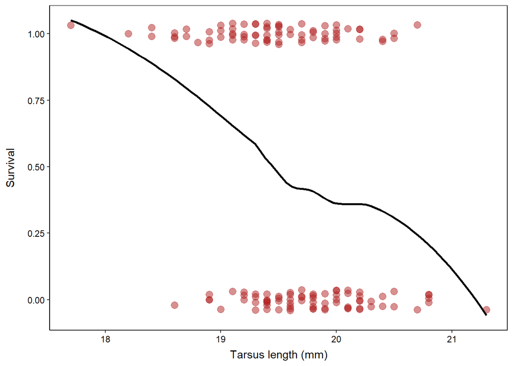

```r
# plot tarsus length vs survival
# geom_jitter is an alternative to geom_point, but it presents the points
# in a clearer way, especially if there is a lot of overlap
ggplot2::ggplot(data = sparrow.data, aes(x = tarsus, y = survival)) +
  geom_jitter(color = "firebrick", size = 3,
              height = 0.04, width = 0,
              alpha = 0.5) +
  # this adds a trendline
  geom_smooth(method = "loess", linewidth = 1, col = "black", se = FALSE) +
  xlab("Tarsus length (mm)") +
  ylab("Survival")
```

Would you agree that sparrows with shorter tarsi were favoured by natural selection?

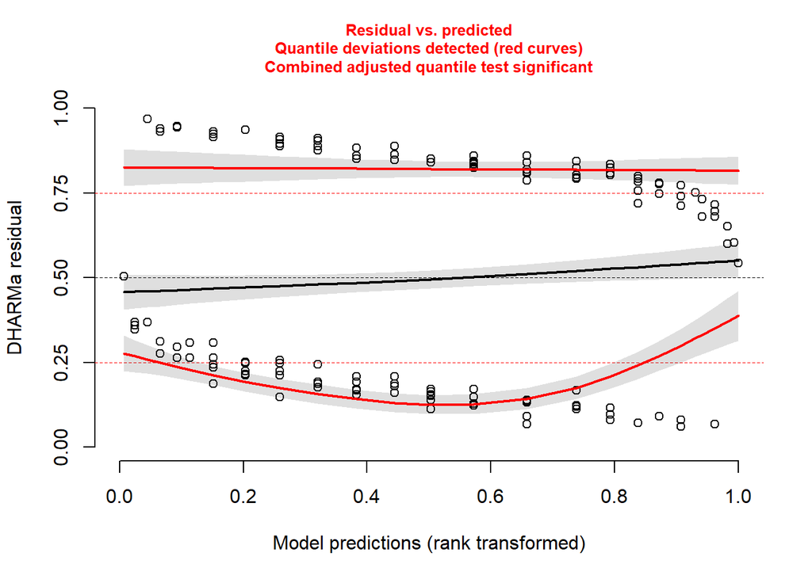

```r
# run a linear model
sparrow.lm = lm(survival ~ tarsus, data = sparrow.data)

# in this residual plot, there are three dashed lines: at the 0.25, 0.5, and
# 0.75 quantiles. We expect to see our solid lines closely following these
# straight lines. You can see how the upper and lower red lines deviate quite
# noticeably
DHARMa::plotResiduals(sparrow.lm)
```

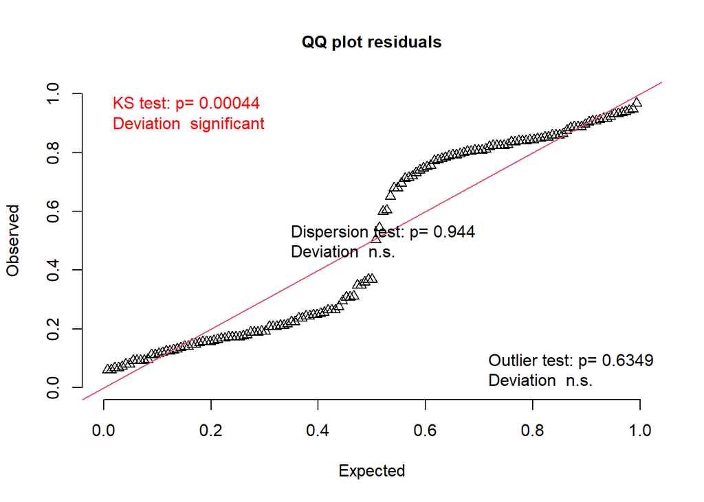

```r
#plot(DHARMa::simulateResiduals(sparrow.lm))

# Here we also see a significant deviation of the KS test (Kolmogorov-Smirnov).
# The KS test is an indication of goodness of fit. At least there is not
# significant overdispersion or outliers in the data.
DHARMa::plotQQunif(sparrow.lm)
```

```r
# Let's run a GLM where we look at the effect of tarsus length on survival
sparrow.glm = glmmTMB::glmmTMB(survival ~ tarsus,
                  family = binomial(link = "logit"),
                  data = sparrow.data)

# we can also run a null model -> assumes that the log-odds of survival is
# consistent across all tarsal measurements (null hypothesis)
sparrow.glm.null = glmmTMB::glmmTMB(survival ~ 1,
                  family = binomial(link = "logit"),
                  data = sparrow.data)

# now we can compare the models
# You can see that model 2, which includes
# tarsus length, is a much better fit than the null model. This difference is
# also significant, as p < 0.05. This just means that tarsal length is a
# significant predictor of survival
anova(sparrow.glm.null, sparrow.glm, test = "Chisq")
```

```
## Data: sparrow.data
## Models:
## sparrow.glm.null: survival ~ 1, zi=~0, disp=~1
## sparrow.glm: survival ~ tarsus, zi=~0, disp=~1
##                  Df    AIC    BIC   logLik deviance  Chisq Chi Df Pr(>Chisq)
## sparrow.glm.null  1 202.95 205.93 -100.475   200.95
## sparrow.glm       2 189.04 195.00  -92.521   185.04 15.908      1   6.65e-05
##
## sparrow.glm.null
## sparrow.glm      ***
## ---
## Signif. codes:  0 '***' 0.001 '**' 0.01 '*' 0.05 '.' 0.1 ' ' 1
```

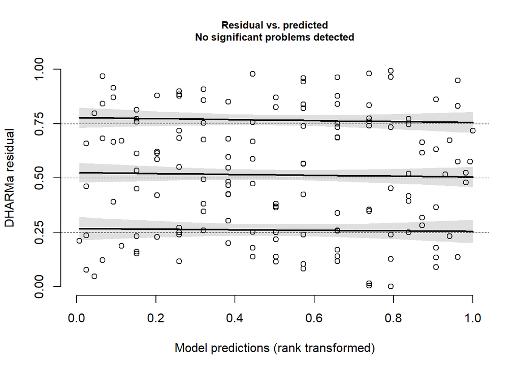

```r
# Check the residuals and QQ plot
DHARMa::plotResiduals(sparrow.glm)
```

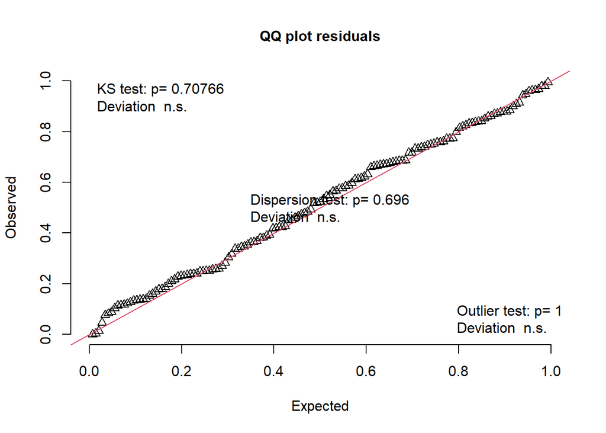

```r
DHARMa::plotQQunif(sparrow.glm)
```

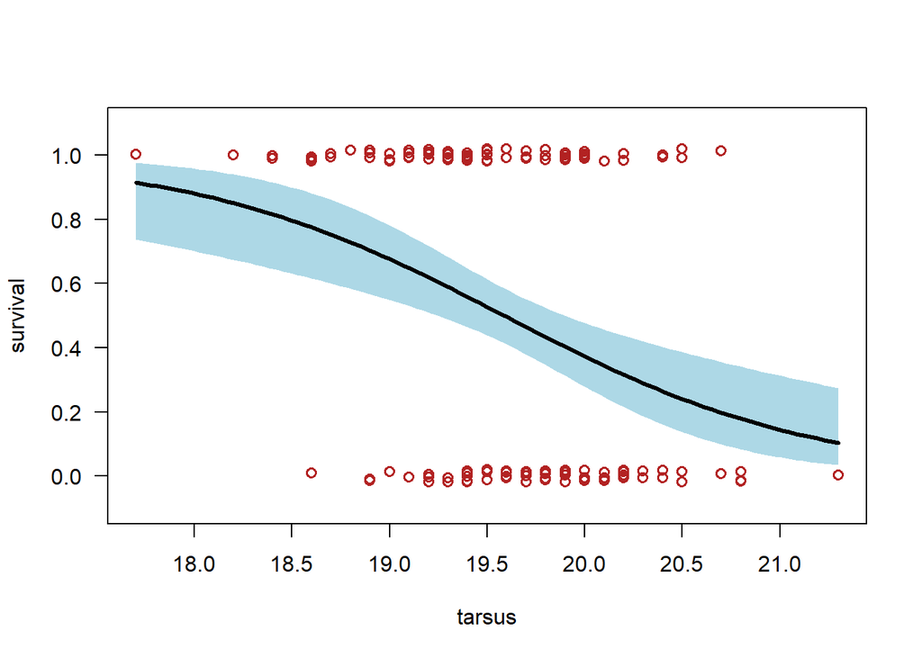

```r
# take a quick peek at the model
visreg::visreg(sparrow.glm, xvar = "tarsus",
               scale = 'response', rug = FALSE,
               ylim = c(-.1, 1.1),
               line.par = list(col = 'black'),
               fill.par = list(col = 'lightblue'))
points(jitter(survival, 0.1) ~ tarsus,
       data = sparrow.data, pch = 1,
       col = "firebrick", lwd = 1.5)
```

```r
# Let's plot this model using ggplot, for practice
# First, we'll add a column to our sparrow.data -> containing predictions
# These are probabilities of survival, based on our GLM
sparrow.data$predictions = predict(sparrow.glm, type = "response")

# Now let's plot in ggplot
sparrow.ggplot = ggplot(sparrow.data, aes(x = tarsus, y = predictions)) +
  geom_point(aes(x = tarsus, y = survival),
             color = "firebrick", size = 3, alpha = 0.6) +
  geom_smooth(method = "glm", method.args = list(family = "binomial"),
              se = TRUE, color = "black", fill = "lightgrey") +
  labs(x = "Tarsus Length", y = "Predicted Survival Probability")
```

```r
# tarsus length has a significant effect on survival
car::Anova(sparrow.glm, test = "Chisq", type = "II")
```

```
## Analysis of Deviance Table (Type II Wald chisquare tests)
##
## Response: survival
##         Chisq Df Pr(>Chisq)
## tarsus 13.391  1  0.0002529 ***
## ---
## Signif. codes:  0 '***' 0.001 '**' 0.01 '*' 0.05 '.' 0.1 ' ' 1
```

```r
summary(sparrow.glm)
```

```
##  Family: binomial  ( logit )
## Formula:          survival ~ tarsus
## Data: sparrow.data
##
##      AIC      BIC   logLik deviance df.resid
##    189.0    195.0    -92.5    185.0      143
##
##
## Conditional model:
##             Estimate Std. Error z value Pr(>|z|)
## (Intercept)  24.6361     6.7454   3.652 0.000260 ***
## tarsus       -1.2578     0.3437  -3.659 0.000253 ***
## ---
## Signif. codes:  0 '***' 0.001 '**' 0.01 '*' 0.05 '.' 0.1 ' ' 1
```

```r
gtsummary::tbl_regression(sparrow.glm, exponentiate = TRUE)
```

| **Characteristic** | **exp(Beta)** | **95% CI**<sup>1</sup> | **p-value** |
| --- | --- | --- | --- |
| tarsus | 0.28 | 0.14, 0.56 | <0.001 |

<sup>1</sup> CI = Confidence Interval

```r
# get the exponential of the beta coefficient, since we ran a logistic
# regression. Note that the sign was negative, which just tells us the
# direction of the effect. R gives the log-odds, we need to get it as an
# odds ratio
odds.ratio = exp(-1.2578)

# percentage
odds.ratio.perc = (odds.ratio - 1)*100

confint(sparrow.glm)
```

```
##                2.5 %     97.5 % Estimate
## (Intercept) 11.41542 37.8568127 24.63612
## tarsus      -1.93147 -0.5841102 -1.25779
```

```r
# get the exponential of the confidence intervals. Note the negative signs
conf.int.lower = exp(-1.97)
conf.int.upper = exp(-0.58)
```

Here we see that tarsus length has a significant effect on survival ($\chi^2$ = 13.4, d.f. = 1, p < 0.001). The beta coefficient value of 0.28 (**exp(-1.2578)**) means that for every millimeter increase in tarsus length, the probability of survival decreases (due to the negative sign) by a factor of **0.28**. As a percentage, this is an approximate **72% reduction** in the odds ([0.28 - 1])*100. The 95% confidence interval suggests that a tarsal length increase of 1 mm will result in a decreased odds of survival at a factor of between 0.14 and 0.56.

```r
predict(sparrow.glm, newdata = data.frame(tarsus = c(22, 20.5, 15, 14)),
        type = "response")
```

```
## [1] 0.04585805 0.24074914 0.99688767 0.99911325
```

Run the same analysis on one or more of the other morphological measurements, and have a look what effect they have on survival.

# **GLM using count data**

## **POISSON AND NEGATIVE BINOMIAL**

Let’s have a look at a quick example of how a GLM can be used to analyse the relationship between the distance to a nuclear power plant (continuous predictor variable, in km), and the number of cases of cancer per year per clinic (count response variable). This data set was taken from the R book second edition by Michael Crawley, chapter 14.

We’ll first apply the **poisson** family to this GLM, since we are dealing with cancer counts. Sometimes there is a lot of variation in count data, which results in overdispersion. In a normal Poisson model, we expect the mean to equal variance, but when it is overdispersed, variance > mean. A negative binomial model is then more suited.

An example of overdispersion might be counts of feeding holes on different plants. The range of feeding holes may be between 0 and 10, but the average is 2. This indicates that there is a lot of variation in the data, and a typical Poisson model [that expects the mean to equal the variance] will underestimate this variation. This will likely result in a model that produces abnormal false positives, and report a predictor variable as being significant when it actually is not. A negative binomial model accounts for this overdispersion, correcting for this.

```r
# read in the data
cancer.data = read.table("data/therbook/clusters.txt", header = T)

head(cancer.data)
```

```
##   Cancers Distance
## 1       0 11.46952
## 2       0 66.55395
## 3       0 47.46230
## 4       0 48.38129
## 5       0 73.76534
## 6       0 70.57555
```

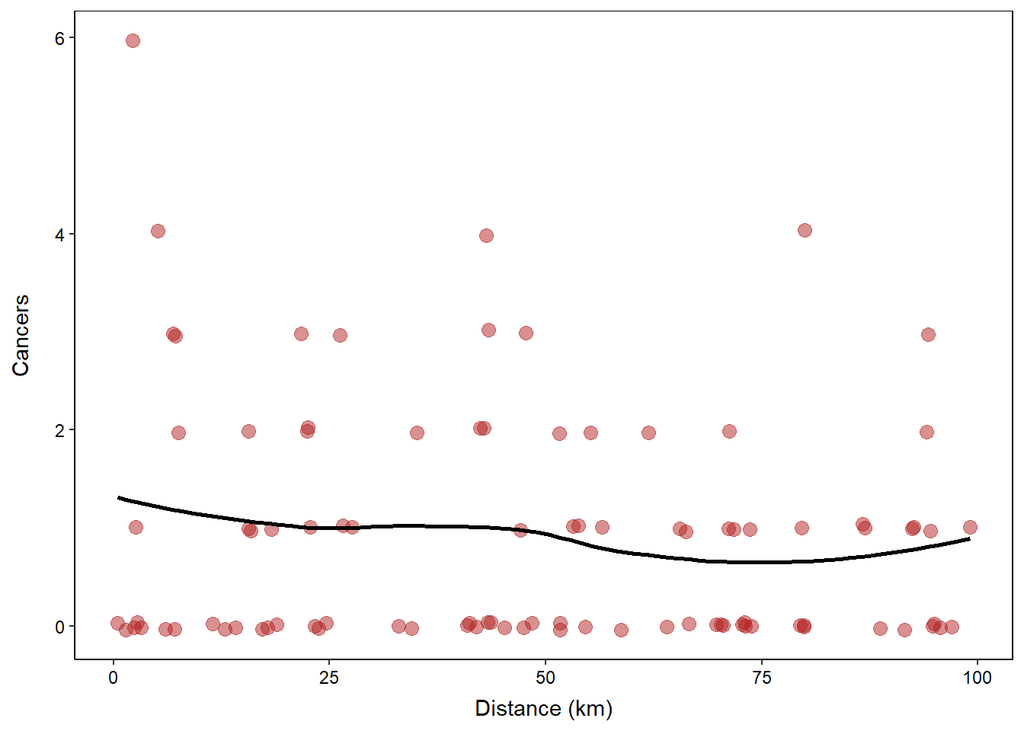

```r
# Let's plot it
ggplot2::ggplot(data = cancer.data, aes(x = Distance, y = Cancers)) +
  geom_jitter(color = "firebrick", size = 3,
              height = 0.04, width = 0,
              alpha = 0.5) +
  # this adds a trendline
  geom_smooth(method = "loess", linewidth = 1, col = "black", se = FALSE) +
  xlab("Distance (km)") +
  ylab("Cancers")
```

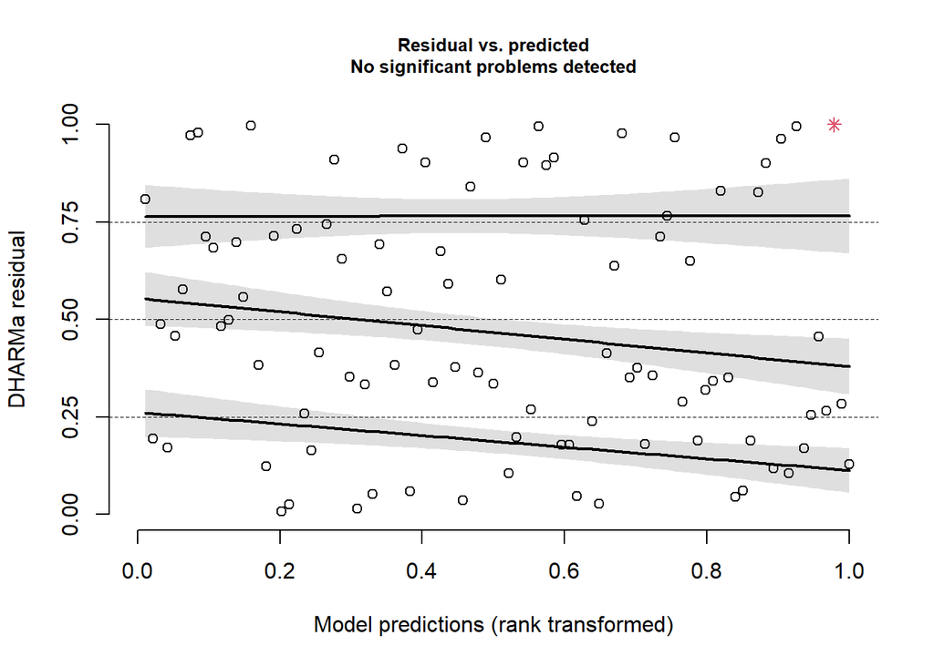

```r
# Run a poisson GLM
cancer.glm.poisson = glm(Cancers ~ Distance, family = poisson,
                         data = cancer.data)

# Another approach, using the glmmTMB library
cancer.glm.poisson.2 = glmmTMB::glmmTMB(Cancers ~ Distance,
                        family = poisson(link = "log"),
                        data = cancer.data)

# Check the residuals and QQ plot
DHARMa::plotResiduals(cancer.glm.poisson)
```

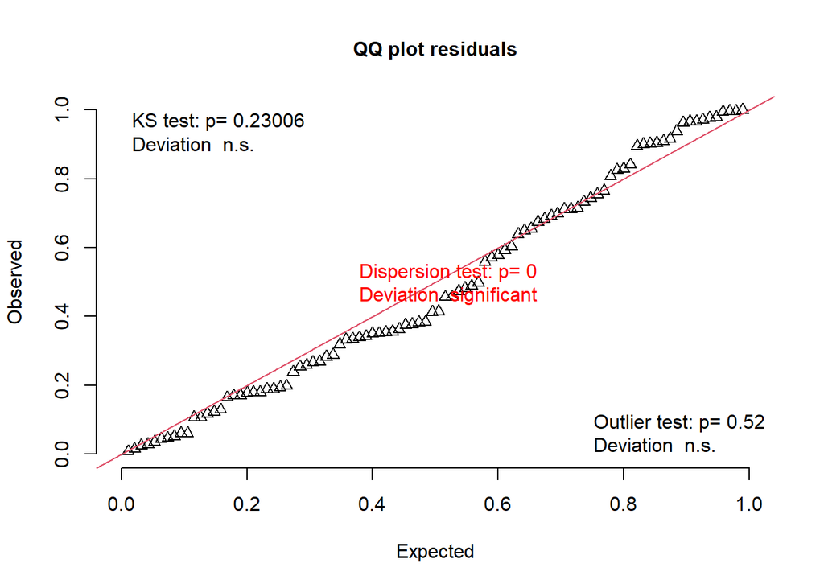

```r
# notice that there is significant overdispersion in the data
DHARMa::plotQQunif(cancer.glm.poisson)
```

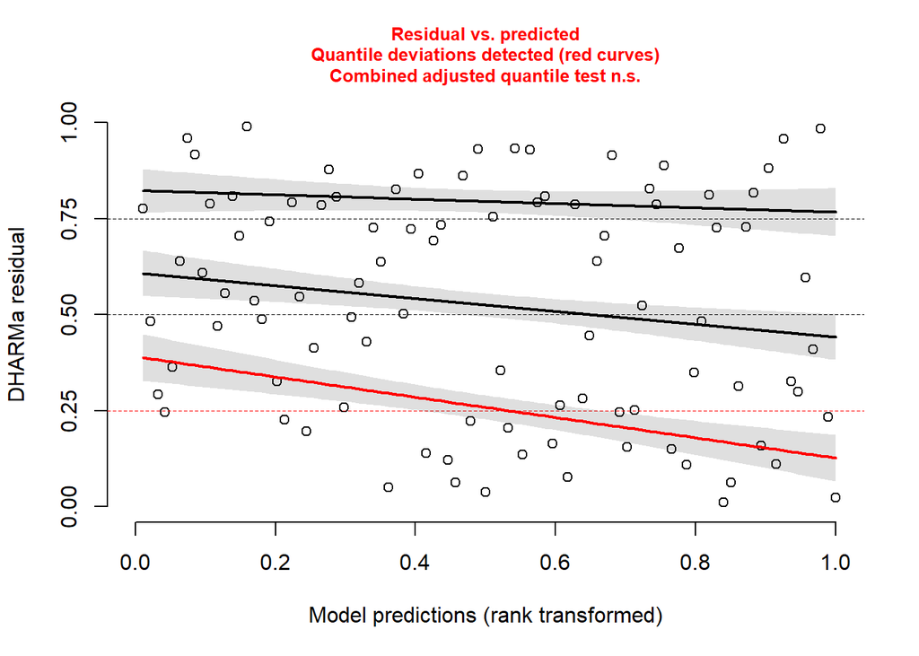

```r
# Run a negative binomial GLM -> this assumes that variance > mean, and is
# often a better fit for most count data, particularly field-collected
cancer.glm.negbin = glmmTMB::glmmTMB(Cancers ~ Distance,
                        family = nbinom2(link = "log"),
                        data = cancer.data)

DHARMa::plotResiduals(cancer.glm.negbin)# Check the residuals and QQ plot
```

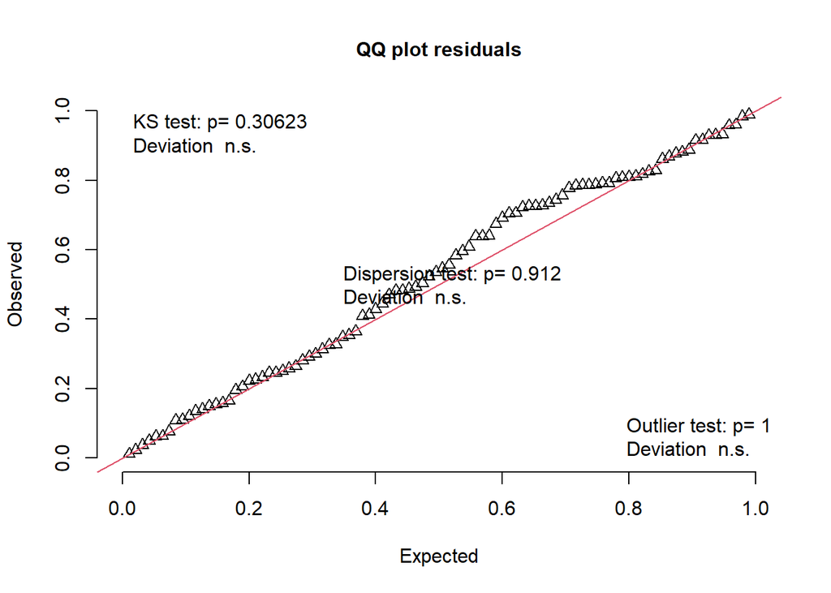

```r
# although the bottom line doesn't look perfect, this model is fine
DHARMa::plotResiduals(cancer.glm.negbin)
# no more overdispersion
DHARMa::plotQQunif(cancer.glm.negbin)
```

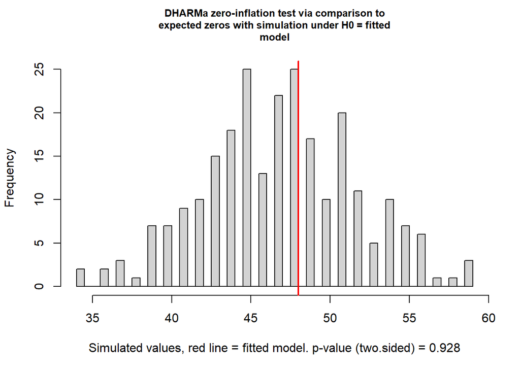

```
##
##  DHARMa zero-inflation test via comparison to expected zeros with
##  simulation under H0 = fitted model
##
## data:  simulationOutput
## ratioObsSim = 1.0197, p-value = 0.928
## alternative hypothesis: two.sided
```

```r
# let's run a test to check whether our data has too many zero values: termed
# "zero inflation"
# since p > 0.05, we do not have an issue with zeroes
DHARMa::testZeroInflation(cancer.glm.negbin)
```

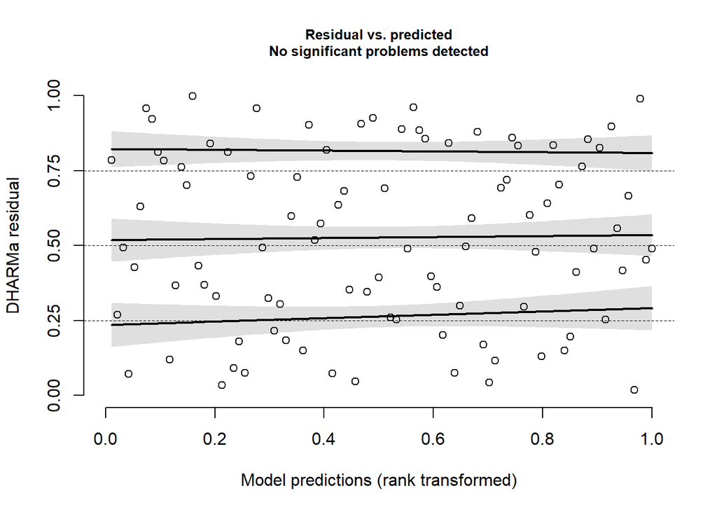

```r
# if we did have an issue with zero-inflation in the Distance variable, we could add an argument to the glmmTMB() function to account for it, using ziformula = ~ Distance
# interestingly, even though there wasn't an issue with zero inflation, when we add this into the model, it seems to improve!

cancer.glm.negbin.zi = glmmTMB::glmmTMB(Cancers ~ Distance,
                        family = nbinom2(link = "log"),
                        ziformula = ~Distance,
                        data = cancer.data)

DHARMa::plotResiduals(cancer.glm.negbin.zi)
```

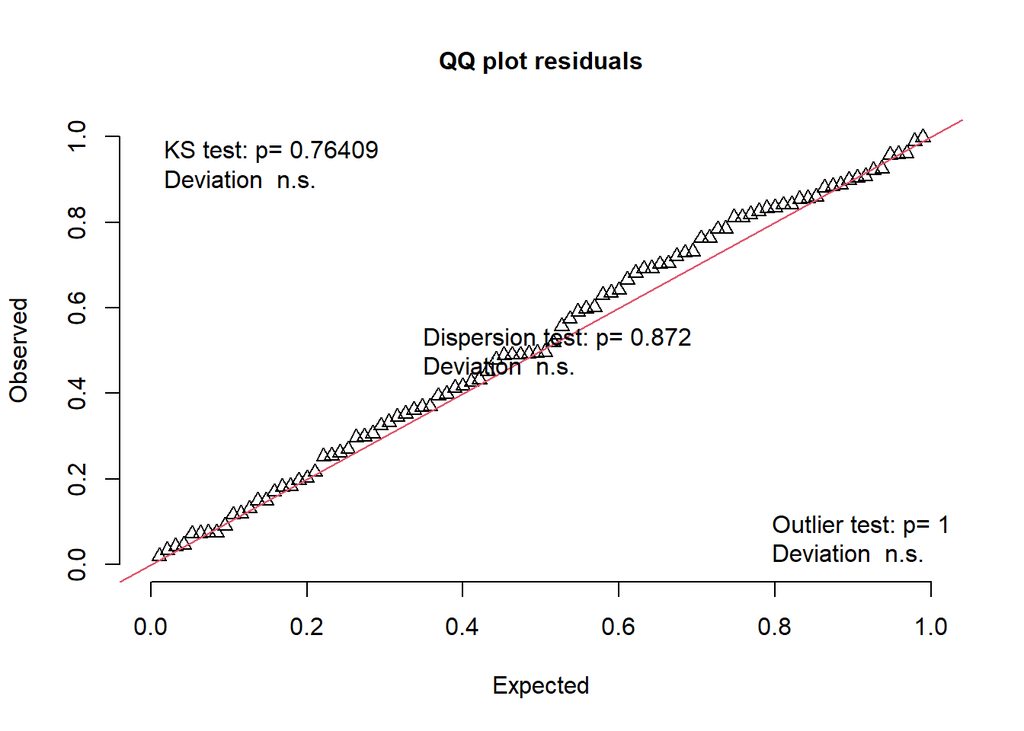

```r
DHARMa::plotQQunif(cancer.glm.negbin.zi)
```

```r
# if we look at the negative binomial vs negative binomial with zero inflation accounted for, there isn't a significant difference between the two models. In this case, go with the simplest one
anova(cancer.glm.negbin, cancer.glm.negbin.zi, test = "Chisq")
```

```
## Data: cancer.data
## Models:
## cancer.glm.negbin: Cancers ~ Distance, zi=~0, disp=~1
## cancer.glm.negbin.zi: Cancers ~ Distance, zi=~Distance, disp=~1
##                      Df    AIC    BIC  logLik deviance  Chisq Chi Df Pr(>Chisq)
## cancer.glm.negbin     3 253.19 260.82 -123.59   247.19
## cancer.glm.negbin.zi  5 252.48 265.19 -121.24   242.48 4.7148      2    0.09466
##
## cancer.glm.negbin
## cancer.glm.negbin.zi .
## ---
## Signif. codes:  0 '***' 0.001 '**' 0.01 '*' 0.05 '.' 0.1 ' ' 1
```

Let’s compare the Poisson and negative binomial models:

```r
gtsummary::tbl_regression(cancer.glm.negbin, exponentiate = TRUE)
```

| **Characteristic** | **exp(Beta)** | **95% CI**<sup>1</sup> | **p-value** |
| --- | --- | --- | --- |
| Distance | 0.99 | 0.98, 1.00 | 0.2 |

<sup>1</sup> CI = Confidence Interval

```r
anova(cancer.glm.poisson.2, cancer.glm.negbin, test = "Chisq")
```

```
## Data: cancer.data
## Models:
## cancer.glm.poisson.2: Cancers ~ Distance, zi=~0, disp=~1
## cancer.glm.negbin: Cancers ~ Distance, zi=~0, disp=~1
##                      Df    AIC    BIC  logLik deviance  Chisq Chi Df Pr(>Chisq)
## cancer.glm.poisson.2  2 262.40 267.49 -129.20   258.40
## cancer.glm.negbin     3 253.19 260.82 -123.59   247.19 11.214      1  0.0008117
##
## cancer.glm.poisson.2
## cancer.glm.negbin    ***
## ---
## Signif. codes:  0 '***' 0.001 '**' 0.01 '*' 0.05 '.' 0.1 ' ' 1
```

```r
car::Anova(cancer.glm.negbin, test = "Chisq", type = "II")
```

```
## Analysis of Deviance Table (Type II Wald chisquare tests)
##
## Response: Cancers
##           Chisq Df Pr(>Chisq)
## Distance 1.6577  1     0.1979
```

```r
summary(cancer.glm.negbin)
```

```
##  Family: nbinom2  ( log )
## Formula:          Cancers ~ Distance
## Data: cancer.data
##
##      AIC      BIC   logLik deviance df.resid
##    253.2    260.8   -123.6    247.2       91
##
##
## Dispersion parameter for nbinom2 family (): 1.36
##
## Conditional model:
##              Estimate Std. Error z value Pr(>|z|)
## (Intercept)  0.182490   0.250903   0.727    0.467
## Distance    -0.006041   0.004692  -1.288    0.198
```

```r
# beta 1 coefficient
exp(-0.006041)
```

```
## [1] 0.9939772
```

The anova() output shows that the negative binomial model provided a significantly better fit than the Poisson model (p < 0.05), and we can also see that it yielded lower AIC, BIC values, and a log likelihood value closer to zero.

Looking at the summary of the negative binomial model, we can conclude that a one kilometer increase in distance results in a decrease in the number of cancer patients by a factor of 0.9939772 -> exp(-0.006041). Or, as a percentage: [0.9939772 - 1] *100 = -0.6% -> i.e. a 0.6% decrease in the number of cancer records for every 1 km increase in distance from the nuclear power plant. However, this result was not significant ($\chi^2$ = 1.7, d.f. = 1, p = 0.198).

# More count data -> horseshoe crabs

## **POISSON AND NEGATIVE BINOMIAL**

Let’s have a look at another example of modelling using counts. [Brockman (1996)](https://onlinelibrary.wiley.com/doi/abs/10.1111/j.1439-0310.1996.tb01099.x) collected morphological data to explore female horseshoe crab (*Limulus polyphemus*) attractiveness to satellite males. The author measured female colour, spine condition, carapace width (cm), mass (kg), and the number of satellite males.

```r
# read in the data
crab.data = read.csv("data/satellites.csv")
head(crab.data)
```

```
##          color    spine width.cm nsatellites mass.kg
## 1       medium both.bad     28.3           8    3.05
## 2  dark-medium both.bad     22.5           0    1.55
## 3 light-medium     good     26.0           9    2.30
## 4  dark-medium both.bad     24.8           0    2.10
## 5  dark-medium both.bad     26.0           4    2.60
## 6       medium both.bad     23.8           0    2.10
```

```r
str(crab.data)
```

```
## 'data.frame':    173 obs. of  5 variables:
##  $ color      : chr  "medium" "dark-medium" "light-medium" "dark-medium" ...
##  $ spine      : chr  "both.bad" "both.bad" "good" "both.bad" ...
##  $ width.cm   : num  28.3 22.5 26 24.8 26 23.8 26.5 24.7 23.7 25.6 ...
##  $ nsatellites: int  8 0 9 0 4 0 0 0 0 0 ...
##  $ mass.kg    : num  3.05 1.55 2.3 2.1 2.6 2.1 2.35 1.9 1.95 2.15 ...
```

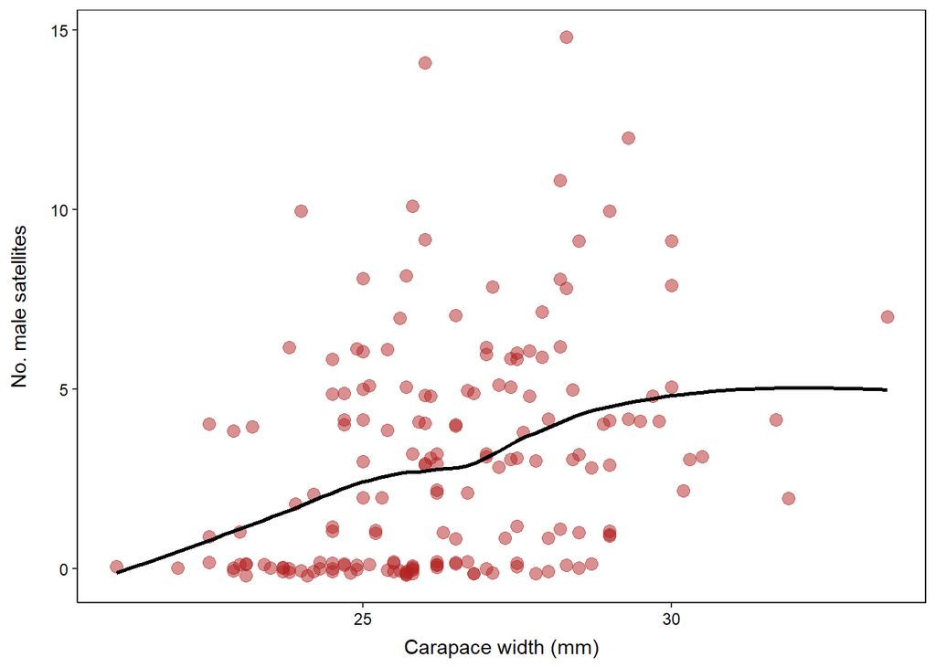

```r
crab.data$color = as.factor(crab.data$color)
crab.data$spine = as.factor(crab.data$spine)

# let's have a look at carapace width versus the number of males
ggplot(data = crab.data, aes(width.cm, nsatellites)) +
  geom_jitter(color = "firebrick", size = 3, height = 0.2, width = 0, alpha = 0.5) +
  geom_smooth(method = "loess", linewidth = 1, col = "black", se = FALSE) +
  labs(x = "Carapace width (mm)", y = "No. male satellites")
```

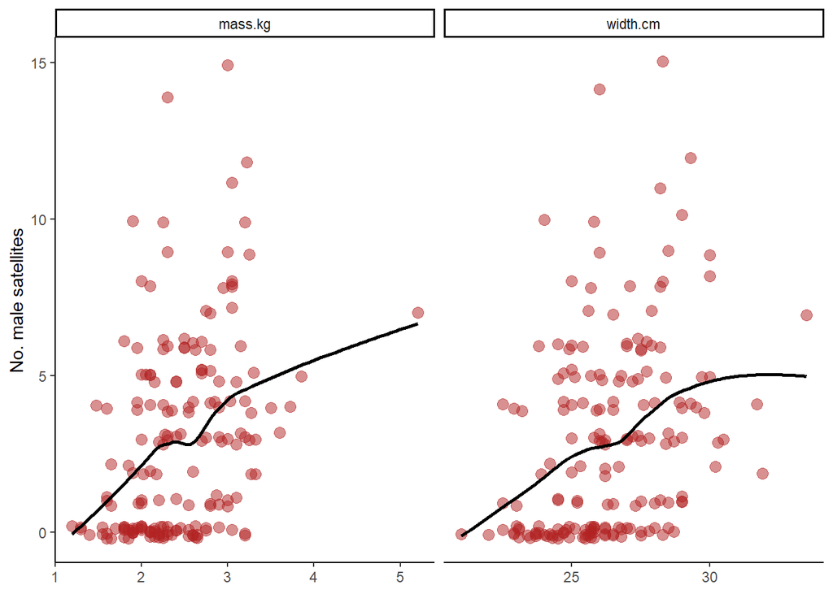

```r
# if you want to plot both mass and width in separate ggplot panels:
crab_long = crab.data %>%
  tidyr::pivot_longer(cols = c(width.cm, mass.kg),
               names_to = "variable", values_to = "value")

# Plot using facets
ggplot(crab_long, aes(value, nsatellites)) +
  geom_jitter(color = "firebrick", size = 3, height = 0.2, width = 0, alpha = 0.5) +
  geom_smooth(method = "loess", linewidth = 1, col = "black", se = FALSE) +
  labs(x = NULL, y = "No. male satellites") +
  facet_wrap(~variable, scales = "free_x") +
  theme_classic()
```

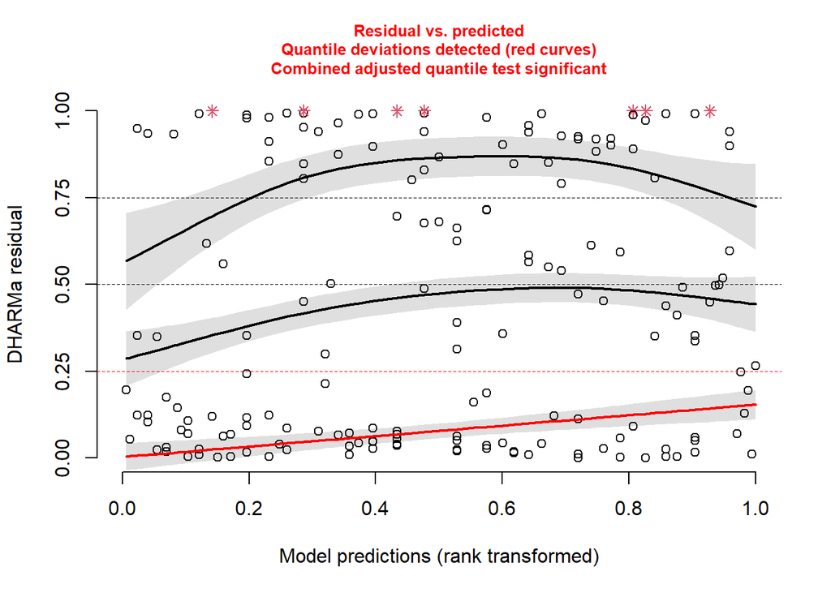

```r
# There appears to be an upward trend, but let's proceed with carapace width
# Let's fit a poisson GLM to find out whether this is significant
crab.glm.poisson = glmmTMB::glmmTMB(nsatellites ~ width.cm,
                       family = poisson(link = "log"), data = crab.data)

# Check the residuals and QQ plot
DHARMa::plotResiduals(crab.glm.poisson)
```

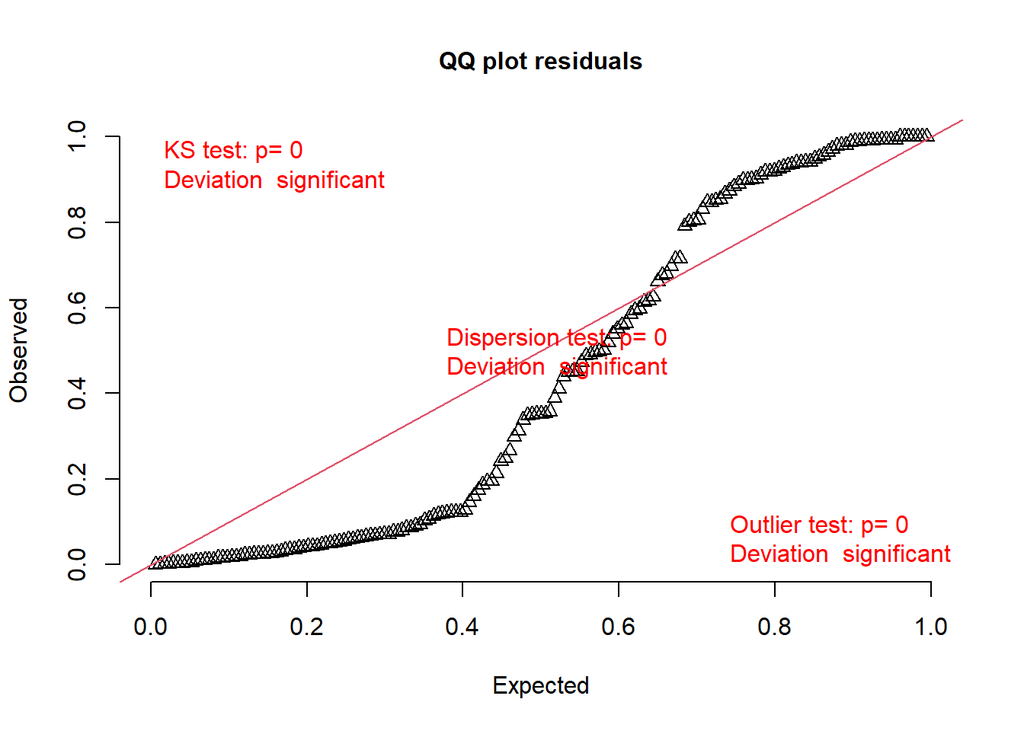

```r
DHARMa::plotQQunif(crab.glm.poisson)
```

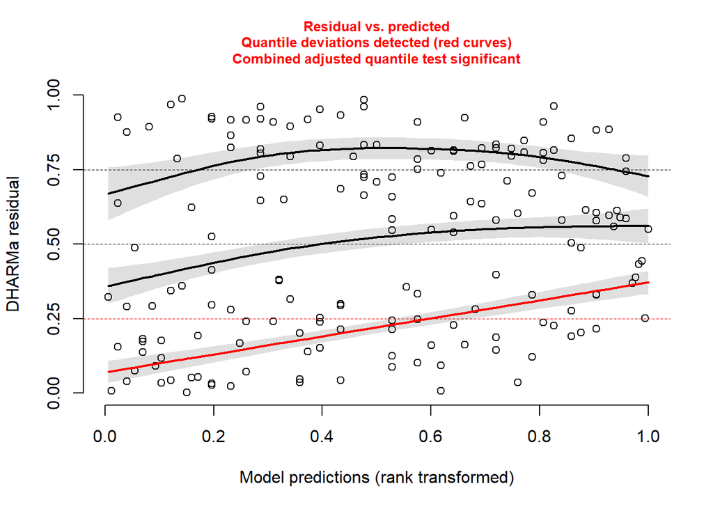

```r
# Let's fit a negative binomial model
crab.glm.negbin = glmmTMB::glmmTMB(nsatellites ~ width.cm,
                       family = nbinom2(link = "log"),
                       data = crab.data)

DHARMa::plotResiduals(crab.glm.negbin)
```

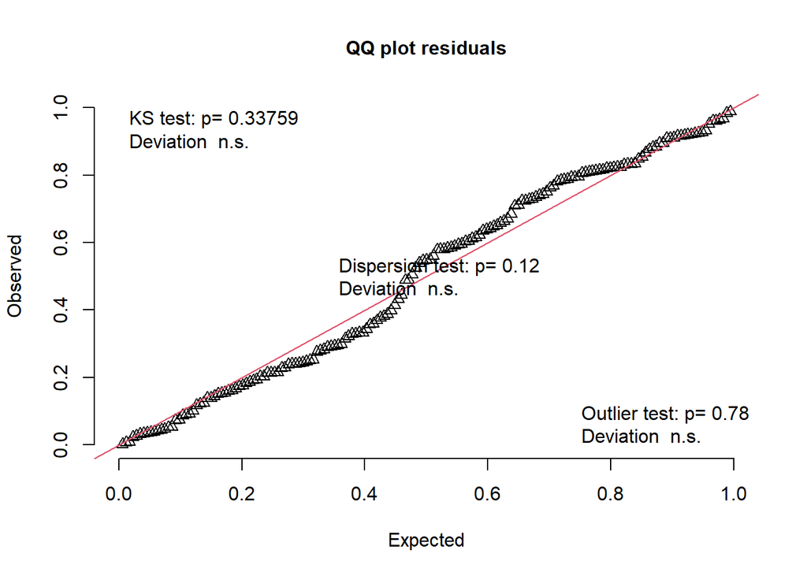

```r
DHARMa::plotQQunif(crab.glm.negbin)
```

```r
# another view of the summary output
gtsummary::tbl_regression(crab.glm.negbin, exponentiate = TRUE)
```

| **Characteristic** | **exp(Beta)** | **95% CI**<sup>1</sup> | **p-value** |
| --- | --- | --- | --- |
| width.cm | 1.21 | 1.10, 1.33 | <0.001 |

<sup>1</sup> CI = Confidence Interval

```r
# compare models -> the negative binomial is significantly better!
anova(crab.glm.poisson, crab.glm.negbin)
```

```
## Data: crab.data
## Models:
## crab.glm.poisson: nsatellites ~ width.cm, zi=~0, disp=~1
## crab.glm.negbin: nsatellites ~ width.cm, zi=~0, disp=~1
##                  Df    AIC    BIC  logLik deviance  Chisq Chi Df Pr(>Chisq)
## crab.glm.poisson  2 927.18 933.48 -461.59   923.18
## crab.glm.negbin   3 757.29 766.75 -375.65   751.29 171.89      1  < 2.2e-16 ***
## ---
## Signif. codes:  0 '***' 0.001 '**' 0.01 '*' 0.05 '.' 0.1 ' ' 1
```

```r
# width does have a significant effect on the number of males
car::Anova(crab.glm.negbin, test = "Chisq", type = "II")
```

```
## Analysis of Deviance Table (Type II Wald chisquare tests)
##
## Response: nsatellites
##           Chisq Df Pr(>Chisq)
## width.cm 16.275  1  5.479e-05 ***
## ---
## Signif. codes:  0 '***' 0.001 '**' 0.01 '*' 0.05 '.' 0.1 ' ' 1
```

```r
summary(crab.glm.poisson)
```

```
##  Family: poisson  ( log )
## Formula:          nsatellites ~ width.cm
## Data: crab.data
##
##      AIC      BIC   logLik deviance df.resid
##    927.2    933.5   -461.6    923.2      171
##
##
## Conditional model:
##             Estimate Std. Error z value Pr(>|z|)
## (Intercept) -3.30476    0.54217  -6.095 1.09e-09 ***
## width.cm     0.16405    0.01996   8.218  < 2e-16 ***
## ---
## Signif. codes:  0 '***' 0.001 '**' 0.01 '*' 0.05 '.' 0.1 ' ' 1
```

```r
summary(crab.glm.negbin)
```

```
##  Family: nbinom2  ( log )
## Formula:          nsatellites ~ width.cm
## Data: crab.data
##
##      AIC      BIC   logLik deviance df.resid
##    757.3    766.8   -375.6    751.3      170
##
##
## Dispersion parameter for nbinom2 family (): 0.905
##
## Conditional model:
##             Estimate Std. Error z value Pr(>|z|)
## (Intercept) -4.05250    1.26399  -3.206  0.00135 **
## width.cm     0.19207    0.04761   4.034 5.48e-05 ***
## ---
## Signif. codes:  0 '***' 0.001 '**' 0.01 '*' 0.05 '.' 0.1 ' ' 1
```

```r
# beta coefficient
exp(0.19207)
```

```
## [1] 1.211755
```

```r
(1.211755 - 1)*100
```

```
## [1] 21.1755
```

```r
# 95% confidence interval
confint(crab.glm.negbin)
```

```
##                   2.5 %     97.5 %   Estimate
## (Intercept) -6.52987449 -1.5751187 -4.0524966
## width.cm     0.09875608  0.2853893  0.1920727
```

```r
exp(0.09875608)
```

```
## [1] 1.103797
```

```r
exp(0.2853893)
```

```
## [1] 1.33028
```

The beta coefficient suggests that for every cm increase in female carapace width, there will be an increase in male satellites by a factor of 1.2 (exp(0.19207)). This equates to an increased odds of an additional male by 21% *(1.211755 - 1) x100*. The 95% confidence interval suggests that a 1 cm increase in female carapace width will yield an increase in males by a factor of between 1.1 and 1.3. Since p < 0.001, we can conclude that female carapace width has a significant effect on the number of satellite males ($\chi^2$ = 16.3, d.f. = 1, p < 0.001).

Let’s include mass as an additional predictor variable:

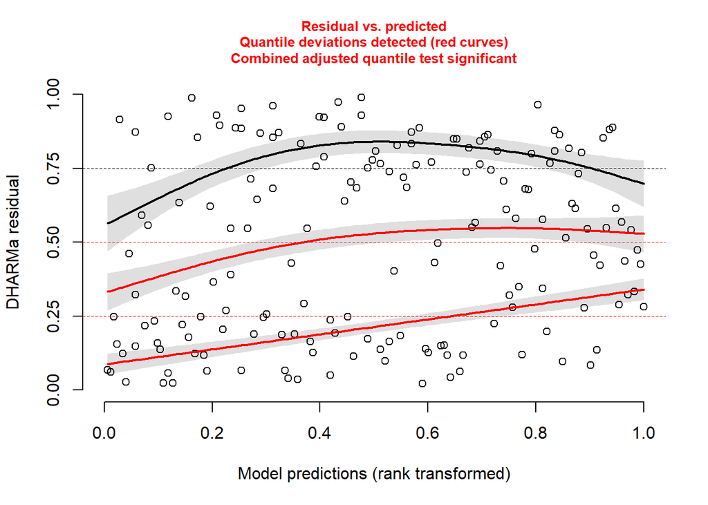

```r
crab.glm.negbin.additive = glmmTMB::glmmTMB(nsatellites ~ width.cm + mass.kg,
                       family = nbinom2(link = "log"),
                       data = crab.data)

DHARMa::plotResiduals(crab.glm.negbin.additive)
```

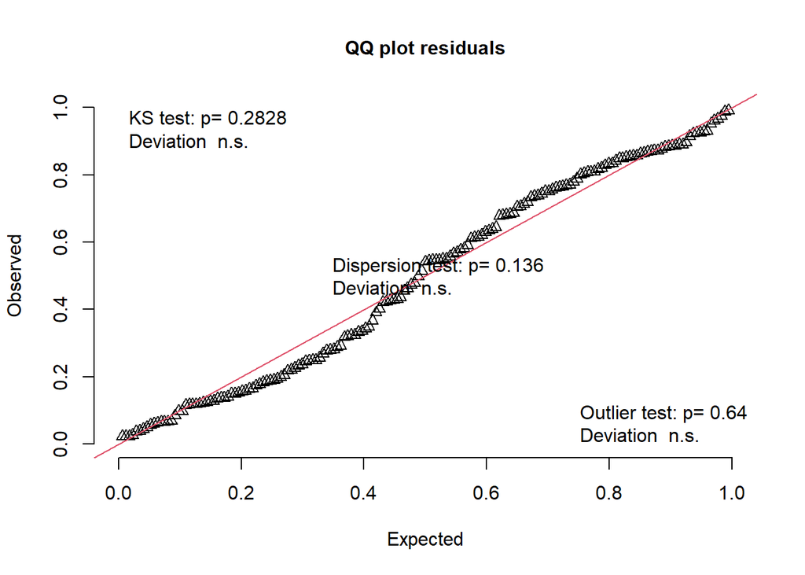

```r
DHARMa::plotQQunif(crab.glm.negbin.additive)
```

```r
# compare models -> there isn't a significant difference between the models
# i.e. adding mass did not improve the model
anova(crab.glm.negbin, crab.glm.negbin.additive)
```

```
## Data: crab.data
## Models:
## crab.glm.negbin: nsatellites ~ width.cm, zi=~0, disp=~1
## crab.glm.negbin.additive: nsatellites ~ width.cm + mass.kg, zi=~0, disp=~1
##                          Df    AIC    BIC  logLik deviance  Chisq Chi Df
## crab.glm.negbin           3 757.29 766.75 -375.65   751.29
## crab.glm.negbin.additive  4 756.57 769.19 -374.29   748.57 2.7182      1
##                          Pr(>Chisq)
## crab.glm.negbin
## crab.glm.negbin.additive    0.09921 .
## ---
## Signif. codes:  0 '***' 0.001 '**' 0.01 '*' 0.05 '.' 0.1 ' ' 1
```

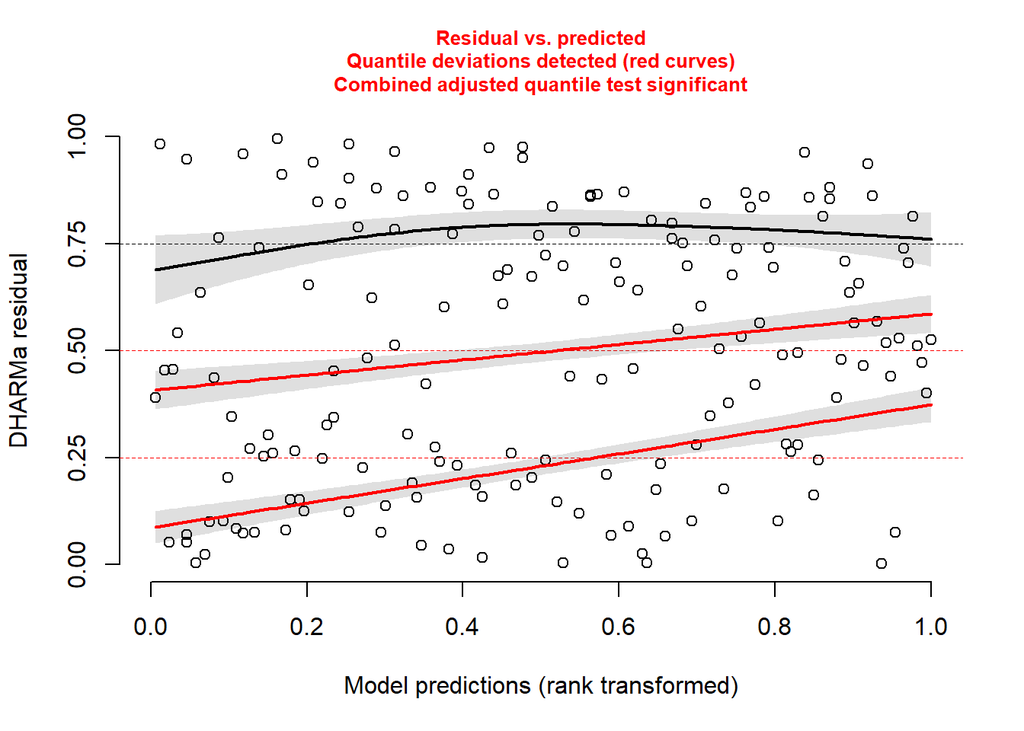

```r
# what if we include width and mass as an interaction term:
crab.glm.negbin.multi = glmmTMB::glmmTMB(nsatellites ~ width.cm * mass.kg,
                       family = nbinom2(link = "log"),
                       data = crab.data)

# we could also write the above as:
# nsatellites ~ width.cm + mass.kg + width.cm:mass.kg

DHARMa::plotResiduals(crab.glm.negbin.multi)
```